# Lab 6: GGPLOT

Makesh Srinivasan

9/21/2021

Registration number: 19BCE1717  
Faculty: Dr. C. Sweetlin Hemalatha  
Slot: L39 + L40  
Course code: CSE3505

## ggplot

1. Plot a bar graph for the number of male and female participants in the survey. Provide the title as “Male and Female participants” and specify the colours for the bars.

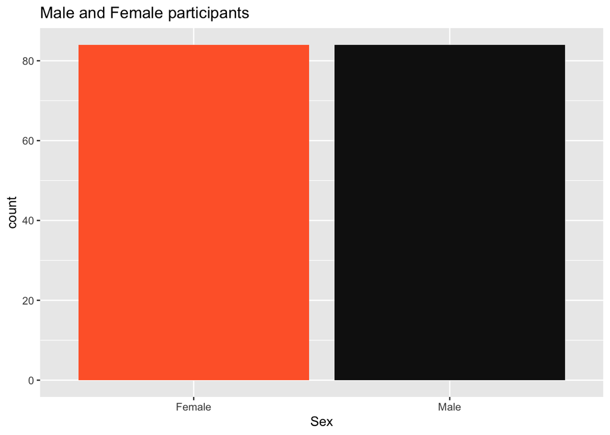

```r
library(MASS)
survey <- survey
df <- unique(survey)
df <- na.omit(survey)
library(ggplot2)
library(dplyr)
ggplot(df,aes(x=Sex))+geom_bar(fill = c("#FF6633","#121212"))+ggtitle("Male and Female participants")
```

2. Plot a bar graph for the number of left handers and right handers in the survey. Provide the title as “Left Handers and Right Handers” and specify the colours for the bars.

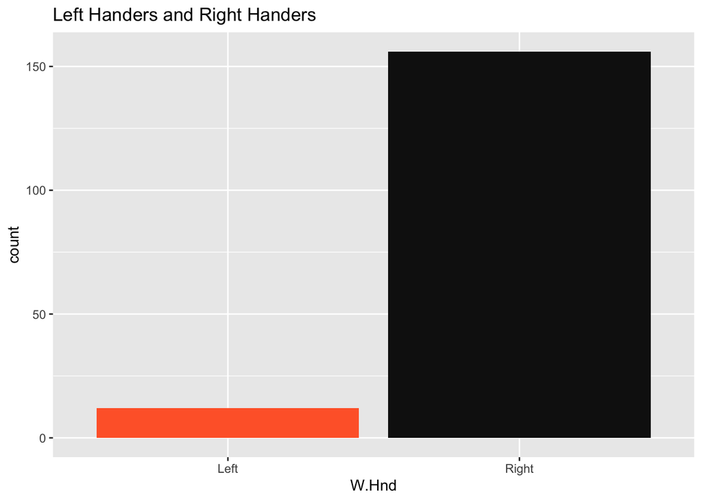

```r
ggplot(df,aes(x=W.Hnd))+geom_bar(fill = c("#FF6633","#121212")) + ggtitle("Left Handers and Right Handers")
```

3. Plot the distribution between male left handers and female left handers using bar chart. Provide the title as “Female Left Handers and Male Left Handers” and specify the colours for the bars.

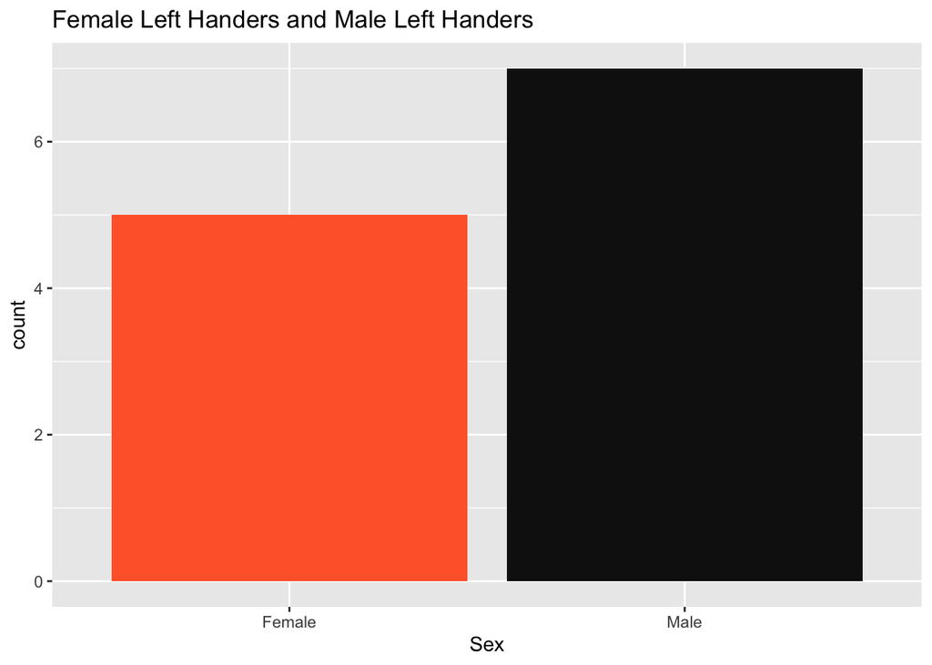

```r
df1 <- df %>%
  filter(W.Hnd == "Left")

ggplot(df1 ,aes(x=Sex))+geom_bar(fill = c("#FF6633","#121212")) + ggtitle("Female Left Handers and Male Left Handers")
```

4. Draw the distribution of smoking habits of male left handers based on age using pie chart.

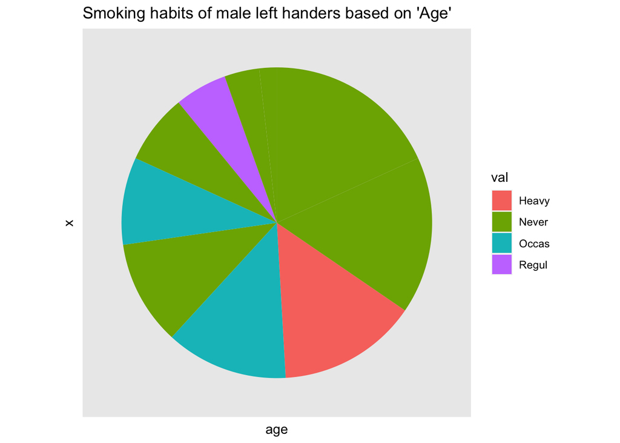

```r
df2 <- survey %>%
  filter(Sex == "Male" & W.Hnd == "Left")

age <- factor(df2$Age)
val <- factor(df2$Smoke)

ggplot(df2, aes(x="",y=age,fill=val))+geom_bar(width=1,stat ='identity')+coord_polar("y",start=0)+ggtitle("Smoking habits of male left handers based on 'Age'")+ theme(axis.text = element_blank(),axis.ticks=element_blank(),panel.grid = element_blank())
```

5. Draw the histogram of age distribution with the title as ‘Age distribution’ and xlabel as ‘Age range’ and ylabel as ‘frequency’.

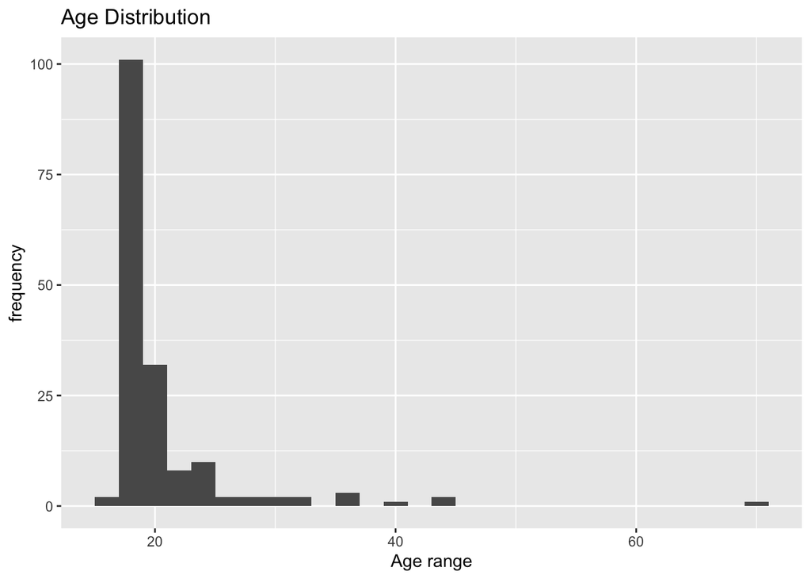

```r
ggplot(df,aes(x = Age))+geom_histogram(binwidth=2)+labs(title = "Age Distribution", x="Age range",y="frequency")
```

6. Reveal the relationship between the age and writing hand span using scatter plot.

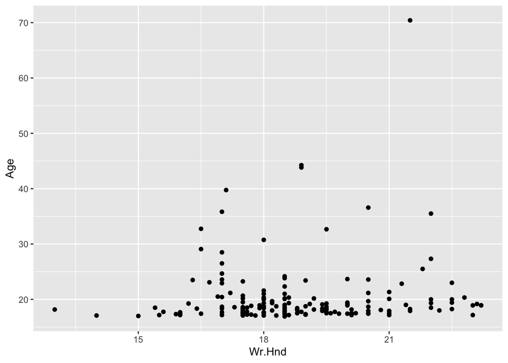

```r
ggplot(df,aes(x=Wr.Hnd,y=Age))+geom_point()
```

7. Plot the distribution of writing hand span vs. pulse rate of left handers. Provide colour based on gender and vary the size of the point based on height of the student.

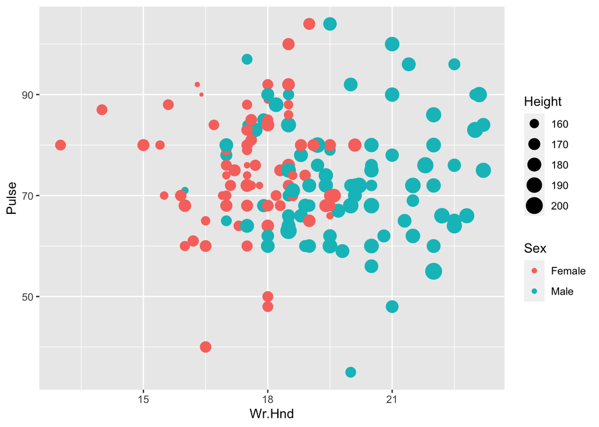

```r
ggplot(df ,aes(x=Wr.Hnd,y=Pulse,size=Height,color=Sex))+geom_point()
```

8. Plot the distribution of height of the students with filled colour based on gender with facet based on left and write handers.

```r
unique(df$W.Hnd)
```

```
## [1] Right Left
## Levels: Left Right
```

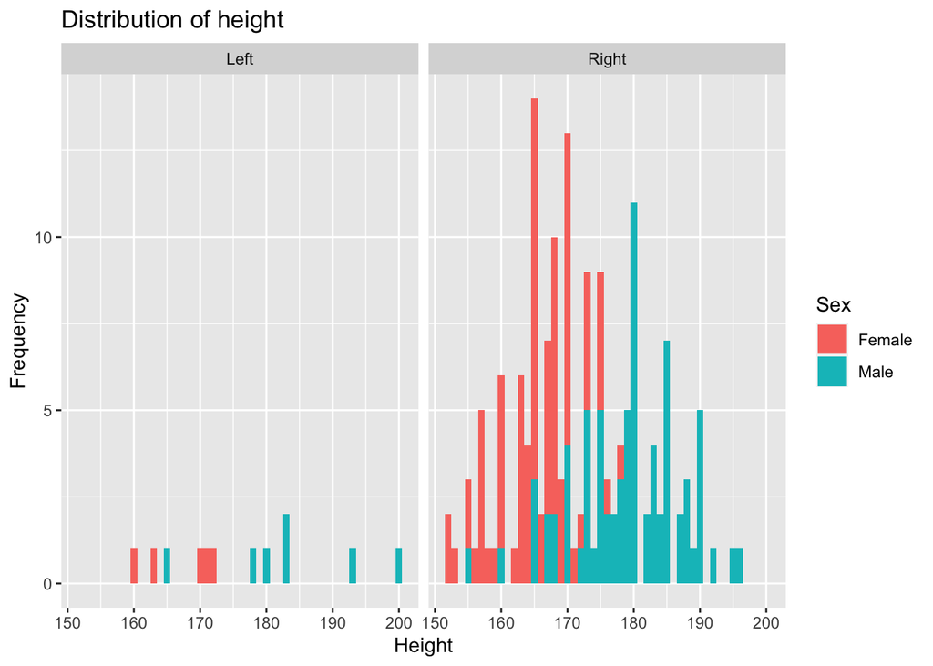

```r
gf = factor(df$W.Hnd,levels = c("Left","Right"),labels = c("Left","Right"))
ggplot(df,aes(x=Height,fill=Sex))+geom_histogram(binwidth = 1)+labs(title = "Distribution of height",y='Frequency')+facet_wrap(gf,ncol=2)
```

9. Plot the trend of span of writing hand vs. non-writing hand coloured and grouped based on left and right handers with facet label based on clap.

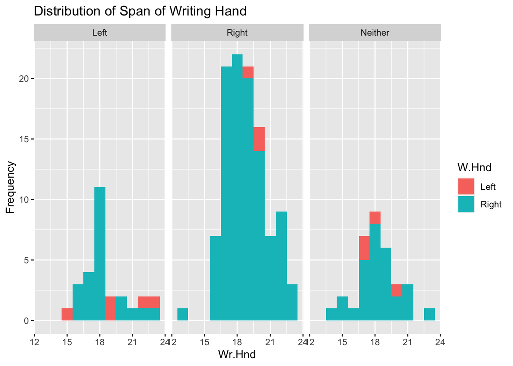

```r
df4 = factor(df$Clap,levels = c("Left","Right","Neither"),labels= c("Left","Right","Neither"))

#Writing Hand
ggplot(df,aes(x=Wr.Hnd, fill=W.Hnd))+geom_histogram(binwidth = 1)+labs(title = "Distribution of Span of Writing Hand",y='Frequency')+facet_wrap(df4,ncol=3)
```

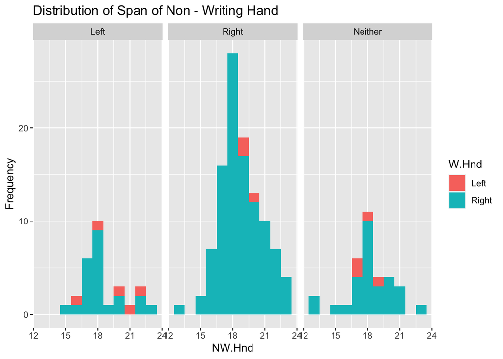

```r
#Non Writing Hand
ggplot(df,aes(x=NW.Hnd,fill=W.Hnd))+geom_histogram(binwidth = 1)+labs(title = "Distribution of Span of Non - Writing Hand",y='Frequency')+facet_wrap(df4,ncol=3)
```

10. Plot the distribution of age of students based on categories under exercise with facet wrap based on gender.

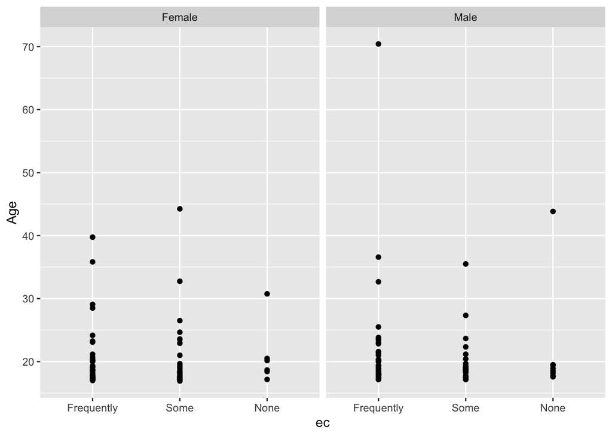

```r
gf = factor(df$Sex,levels = c("Female","Male"),labels = c("Female","Male"))
ec = factor(df$Exer, levels = c("Freq","Some","None"),labels = c("Frequently","Some","None"))
ggplot(df,aes(x=ec,y = Age))+geom_point()+facet_wrap(gf,ncol=3)
```

11. Plot the box plot of writing hand span with respect to smoking habits of students.

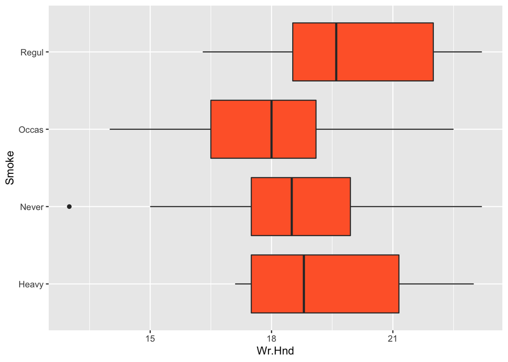

```r
ggplot(df, aes(x=Wr.Hnd,y=Smoke))+geom_boxplot(fill = "#FF6633")
```